# Moodle Group 1 Qs

Braden Baker

3/24/2021

## Question 1: How Long Does it Take for Students to View Their Feedback

Most students viewed their feedback within a couple days but every class had outliers where a student would not view their feedback for days. This data also does not include students that never checked their feedback.

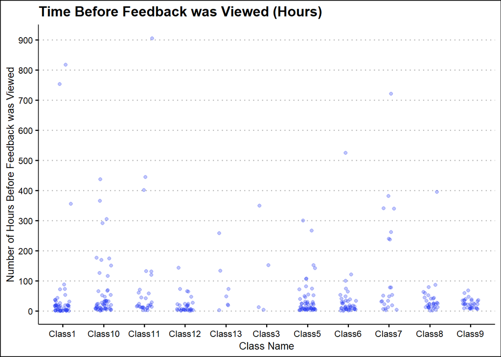

Generally, 80% of the time it can be expected that a student will view their feedback within about 50 hours from the time their feedback was posted.

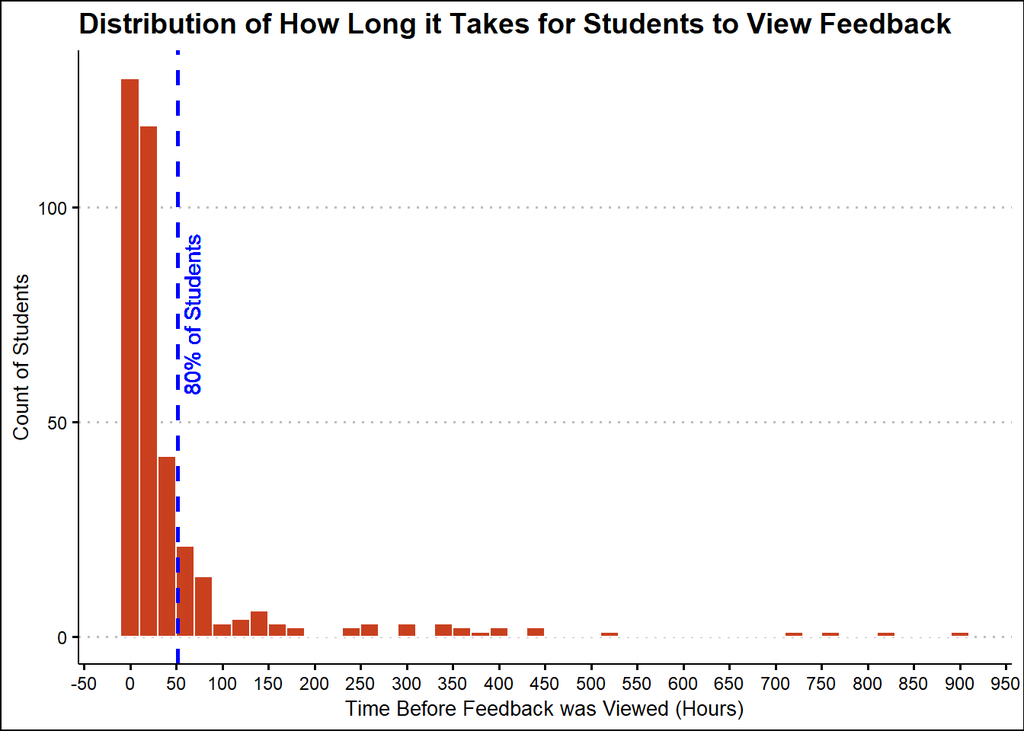

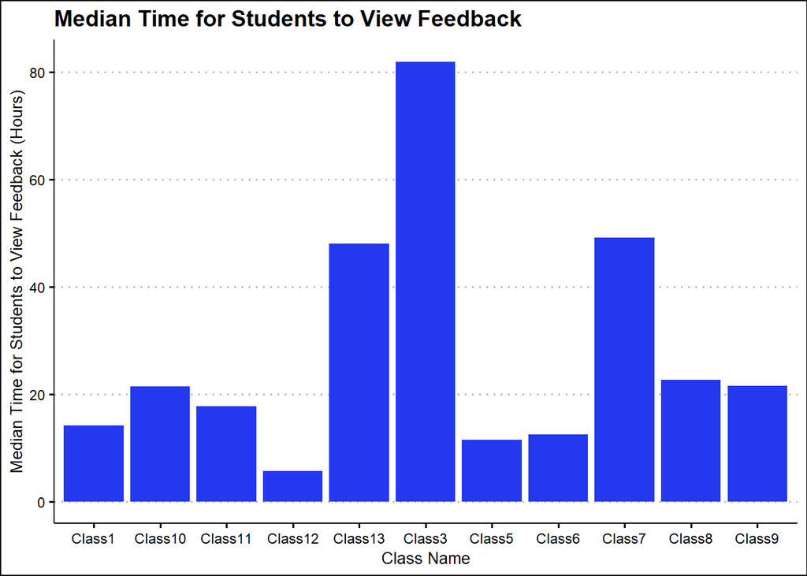

## Question 2: Which Moodle Resources get the Most and Least Number of Interactions

An assignment module received the most views as expected. The next highest view was files which also had the highest number of modules added so its high view count is expected.

The viewership of URL is surprising since it had a large number of modules added. The other module types having low viewership is expected given their lower number of modules to viewed.

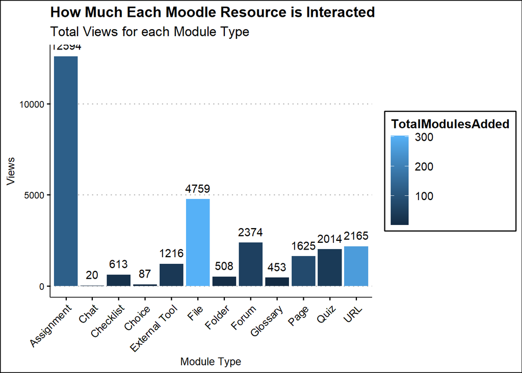

```
## # A tibble: 12 x 4
##    Moduletype    TotalModuleviews TotalModulesAdded ViewsPerModule
##  * <chr>                    <int>             <int>          <dbl>
##  1 Assignment               12594               128          98.4
##  2 Chat                        20                 1          20
##  3 Checklist                  613                16          38.3
##  4 Choice                      87                 1          87
##  5 External Tool             1216                35          34.7
##  6 File                      4759               304          15.7
##  7 Folder                     508                 9          56.4
##  8 Forum                     2374                55          43.2
##  9 Glossary                   453                 1         453
## 10 Page                      1625                79          20.6
## 11 Quiz                      2014                38          53
## 12 URL                       2165               261           8.30
```

When looking at views per module, glossary is clearly at the top. Only one glossary modules was posted in the sample of logs but 450 views is very high and suggests it was used by students frequently. The choice model was similar, it was only used in one course by received quite a view views.

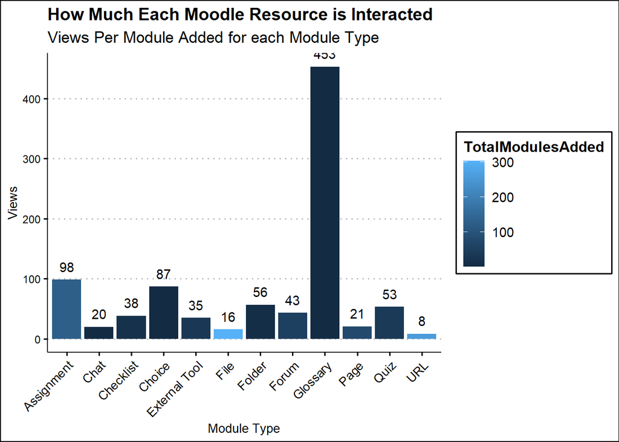

Students viewed most non assignment modules 1-2 times with the exception of choices, folders, and quizzes.

How to read, assignment received an average of 103 views per module added, each student viewed an assignment module on average 7 times, and each class had an average of 10 assignment modules added

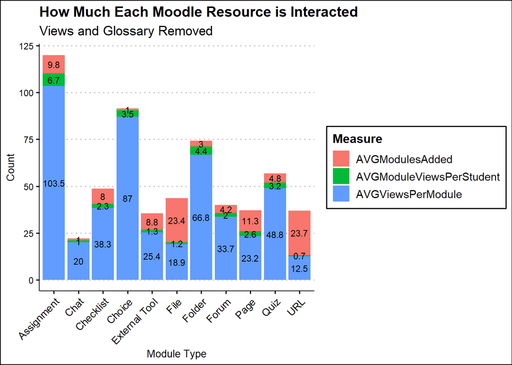

```
## # A tibble: 12 x 5
##    Moduletype AVGTotalModulev~ AVGModulesAdded AVGViewsPerModu~ AVGModuleViewsP~
##  * <chr>                 <dbl>           <dbl>            <dbl>            <dbl>
##  1 Assignment             969.            9.85            103.             6.69
##  2 Chat                    20             1                20              1
##  3 Checklist              306.            8                38.3            2.30
##  4 Choice                  87             1                87              3.48
##  5 External ~             304             8.75             25.4            1.34
##  6 File                   366.           23.4              18.9            1.20
##  7 Folder                 169.            3                66.8            4.36
##  8 Forum                  183.            4.23             33.7            1.97
##  9 Glossary               453             1               453             19.7
## 10 Page                   232.           11.3              23.2            2.65
## 11 Quiz                   252.            4.75             48.8            3.22
## 12 URL                    197.           23.7              12.5            0.700
```

## How Often are Students Viewing Recorded Lectures?

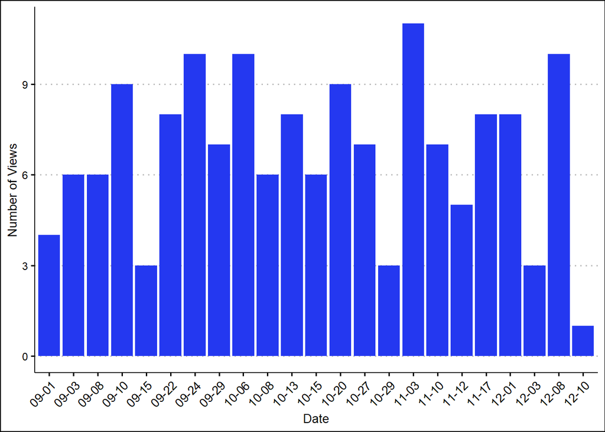

```r
ggplot(q31, aes(x=Date, y=Views)) +
  geom_col(fill = "#2438f0") +
  theme_clean() +
  theme(axis.text.x = element_text(angle = 45, hjust = 1, size = 10)) +
  labs(Title = "Distrubtion of views For Each Recorded Lecture",
       X = "Date Recording Posted",
       y = "Number of Views")
```

Most students viewed a recorded lecture within 5 days of a recording being posted. However another decently sized group viewed the recording lecture 13+ days after posting.

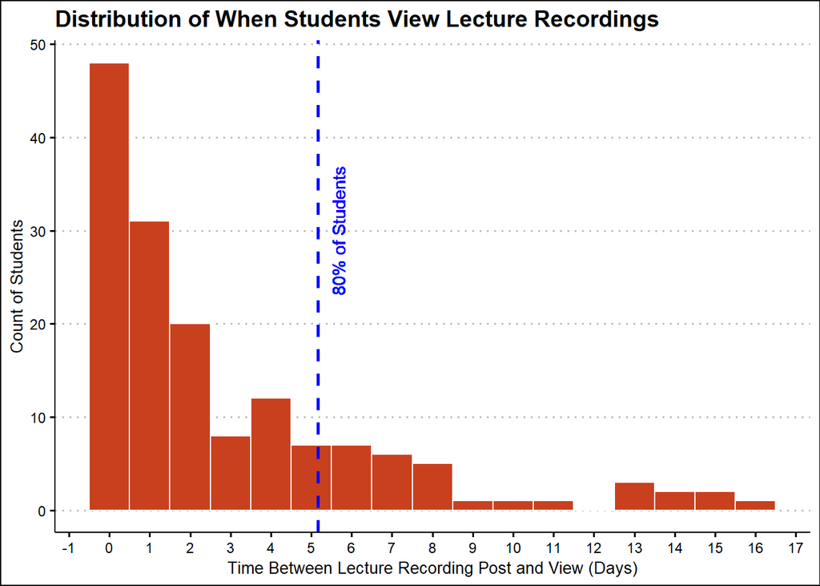

Examining further, it does seem that their may be two groups of views for recording lectures. One group views a few days after a recording is posted likely for homework, missing the class, or just going over it again. A second group viewes the recorded lecture days after it was posted likely for test preperation. This trend is strongest in November. Most November lectures received more views than other months later than the normal 5 days suggesting that the views may have been for prepared for end of semester exams or finals.

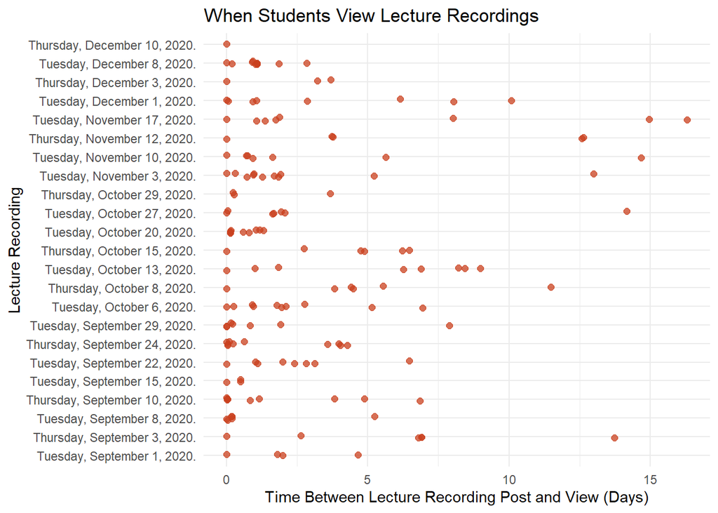